# 第2回 ミクロ/マクロ①：企業財務比率

## ヤマトと SG の 4 指標

実データはヤマトと SG ホールディングス（佐川急便の親会社）  
どちらも有価証券報告書（2026年3月期・連結）の掲載値から計算

| 指標（%・当期） | ヤマト | SG |
| --- | --- | --- |
| 流動比率 | 155.0 | 86.1 |
| 自己資本比率 | 45.5 | 44.6 |
| 売上高利益率 | 0.7 | 3.6 |
| ROE | 2.4 | 10.9 |

- **ヤマト**：第161期・PDF 81〜85 頁。F 列はトピック 1・2 で出した値
- **SG**：第20期・PDF 83〜85 頁。  
  G2〜G11 は印刷済み、G13〜G16 は実習で計算

## 2 社の利益率の棒

1. **貼る**：F13:F16 をコピーし  
   G13 に貼る
2. **選ぶ**：F1:G1 を選び、Ctrl を  
   押しながら F15:G15
3. **描く**：集合縦棒を挿入し  
   題を「売上高利益率（%）」に

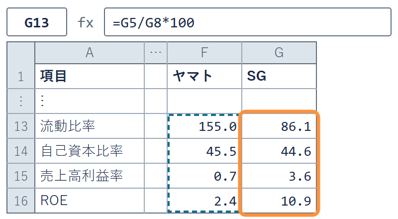

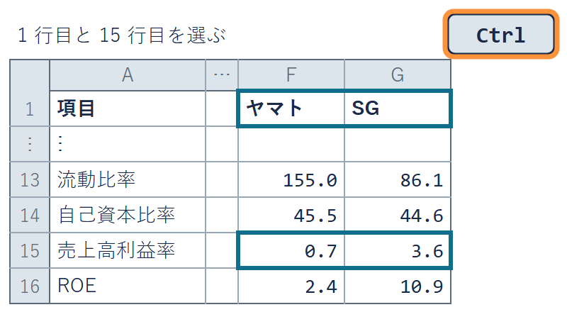

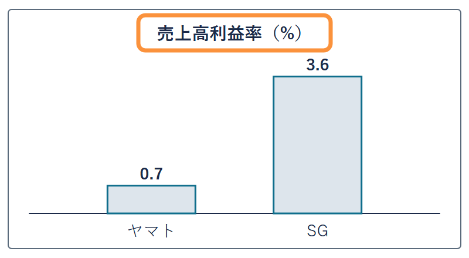

F13〜F16 はトピック 1・2 で出したヤマトの値。SG の棒は約 5 倍

✋ 動画を止めて STEP 1〜3 を進め、G15 が 3.6 なら再生に戻る

## 演習 2-4-1 利益の減少と棒の順

演習 2-4-1

製造 A 社の利益が 80 億円に減ると、棒の順はどうなるか

1. **変える場所**：B3（製造 A 社の当期純利益）を 400 から 80 に
2. **考える問い**：棒の高い順はどう変わるか。先に予想してから打つ
3. **答えを打つ**：K15（演習 2-4-1 の行）に、高い順の会社名を打つ
4. **終わりの条件**：K15 に打ったら、B3 を 400 に戻す

✋ 動画を止めて 2 分。K15 に打ち、B3 を戻したら再生に戻る

## 演習 2-4-1 の答え

演習 2-4-1 の答え

IT C 社・小売 B 社・製造 A 社の順（製造 A 社は 1.0）

- **式の中身**：80 ÷ 8,000 × 100 ＝ 1.0
- **棒も動く**：グラフは B15 とつながっていて、描き直さなくてよい
- **読み方**：棒の高さは、いつもセルの値そのもの
- **答え欄**：K15 に「IT C 社・小売 B 社・製造 A 社」と打てていれば正解

## 3 社の流動比率と平均

[figure not shown]

- **サンプルデータ**：架空。「比率」シートの 13 行目（トピック 1 の値）
- **問い**：平均を 100 とすると、製造 A 社の 150.0 はいくつか

✋ 予想する — 100 より上／ちょうど 100／100 より下

## 平均で割る計算

平均を出してから、1 社ずつ平均で割って 100 倍する

- **平均**：(150.0 ＋ 120.0 ＋ 280.0) ÷ 3 ＝ 183.33…
- **製造 A 社**：150.0 ÷ 183.33… × 100 → 81.8
- **小売 B 社**：120.0 ÷ 183.33… × 100 → 65.5
- **IT C 社**：280.0 ÷ 183.33… × 100 → 152.7

平均ちょうどの会社があれば、その会社は 100 になる

## 指数の棒と 100 の線

[figure not shown]

平均の線が 100 の線になり、上下の位置はそのまま残る

- **サンプルデータ**：lec2-exercise.xlsx の「比率」シート

## 指数の定義

定義

**指数 ＝ 値 ÷ 基準の値 × 100**  
基準を 100 としたとき、その会社がどの位置にいるか

- **100 より下**：その指標が平均より低い。製造 A 社の 81.8 がそれ
- **今回の基準**：3 社（実データでは 2 社）の平均。どの指標も平均が 100
- **使える場面**：ニュースの物価指数も、基準を 100 にそろえた数

大きさの次は、水準を相対にそろえる

## 3 社の指数

1. **平均**：E13 に `=AVERAGE(B13:D13)`  
   E16 まで下へ引く
2. **3 本の式**：B27 に `=B13/E13*100`  
   C27 に `=C13/E13*100`  
   D27 に `=D13/E13*100`
3. **下へ引く**：B27:D27 を  
   30 行目まで
4. **そろえる**：E13:E16 と B27:D30 で  
   `Ctrl + 1`（Mac は `⌘ + 1`）  
   → 数値・小数点以下 1 桁

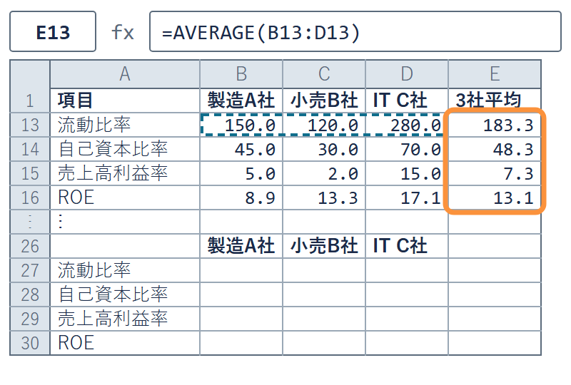

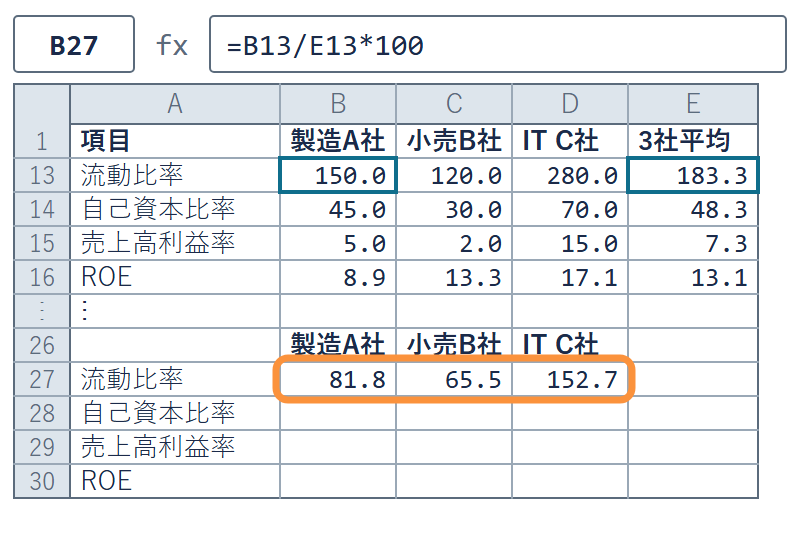

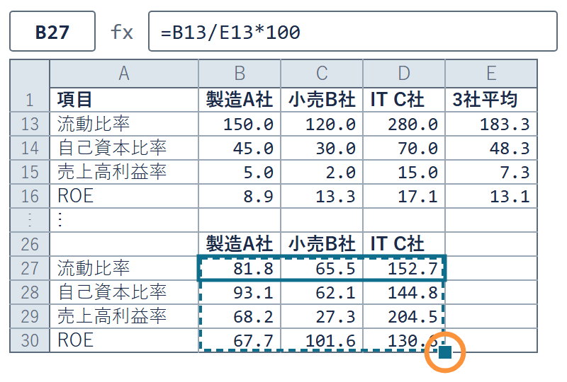

✋ 動画を止めて STEP 1〜4 を進め、B27 が 81.8 なら再生に戻る

## 平均の列のずれ

B27 を右へ引く  
C27 が `=C13/F13*100`  
小売 B 社 **77.4**

3 本とも打つ（正しい）  
C27 は `=C13/E13*100`  
小売 B 社 **65.5**

- **なぜ起きるか**：右へ引くと、分母の E13 も F13 へずれる
- **どう防ぐか**：数式バーで、分母が E 列のままかを見る

割る相手の平均は、どの会社でも E 列

## 2 社平均と指数

| 指標（%） | ヤマト | SG | 2 社平均 |
| --- | --- | --- | --- |
| 流動比率 | 155.0 | 86.1 | 120.5 |
| 自己資本比率 | 45.5 | 44.6 | 45.1 |
| 売上高利益率 | 0.7 | 3.6 | 2.2 |
| ROE | 2.4 | 10.9 | 6.6 |

- **基準**：同じ式で、ヤマトと SG の 2 社平均を 100 にする
- **流動比率なら**：ヤマト 128.6・SG 71.4（足すと 200）
- **SG の 86.1**：買収のつなぎの借入で、流動負債が一時的に増えた

出典：ヤマト 有価証券報告書 第161期（PDF 81〜85 ページ）  
SG 有価証券報告書 第20期（PDF 83〜85 ページ）の掲載値から計算

## 2 社の指数

1. **平均**：H13 に `=AVERAGE(F13:G13)`  
   H16 まで下へ引く
2. **2 本の式**：F27 に `=F13/H13*100`  
   G27 に `=G13/H13*100`
3. **下へ引く**：F27:G27 を  
   30 行目まで
4. **そろえる**：H13:H16 と F27:G30 で  
   `Ctrl + 1`（Mac は `⌘ + 1`）  
   → 数値・小数点以下 1 桁

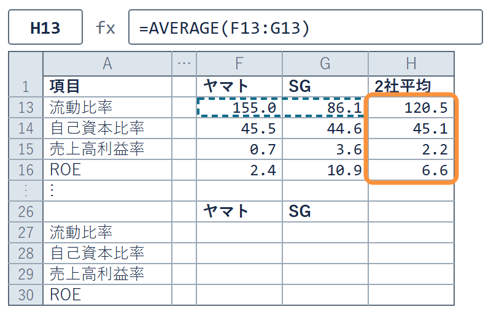

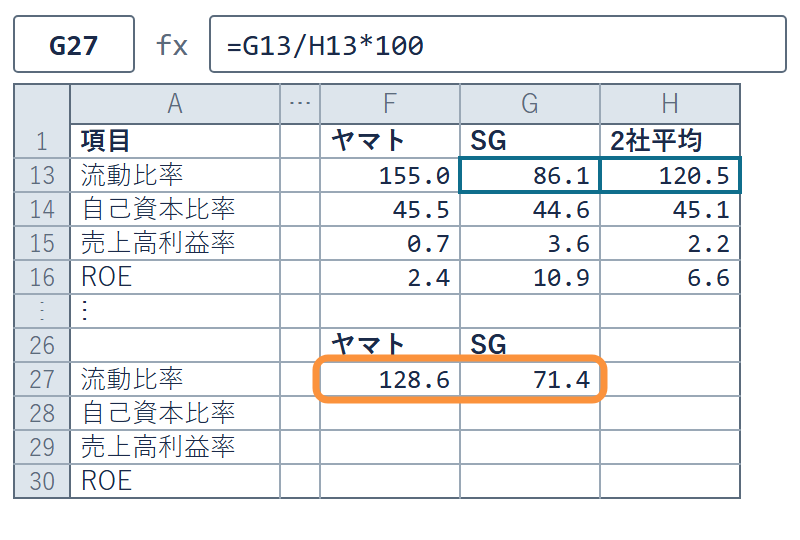

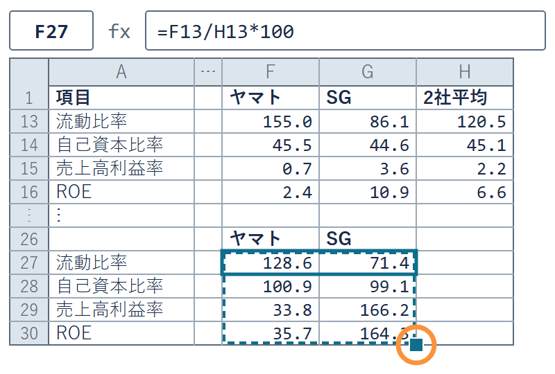

✋ 動画を止めて STEP 1〜4 を進め、F27 が 128.6 なら再生に戻る

## 演習 2-4-2 流動資産の減少と指数

演習 2-4-2

IT C 社の流動資産だけが減ると、製造 A 社の指数はどうなるか

1. **変える場所**：D5（IT C 社の流動資産）を 560 から 300 に
2. **考える問い**：B27 はいくつか。製造 A 社の数は変えていない
3. **答えを打つ**：K16（演習 2-4-2 の行）に、B27 の値を打つ
4. **終わりの条件**：K16 に打ったら、D5 を 560 に戻す

✋ 動画を止めて 2 分。K16 に打ち、D5 を戻したら再生に戻る

## 演習 2-4-2 の答え

演習 2-4-2 の答え

B27 は 107.1（平均が 140.0 に下がったから）

- **IT C 社**：300 ÷ 200 × 100 ＝ 150.0（D13）
- **平均**：(150.0 ＋ 120.0 ＋ 150.0) ÷ 3 ＝ 140.0（E13）
- **製造 A 社**：150.0 ÷ 140.0 × 100 → 107.1（81.8 から上がる）
- **答え欄**：K16 に 107.1 と打てていれば正解

## 4 指標の重ね方の予想

| 指標（%） | 製造 A 社 | 小売 B 社 | IT C 社 |
| --- | --- | --- | --- |
| 流動比率 | 150.0 | 120.0 | 280.0 |
| 自己資本比率 | 45.0 | 30.0 | 70.0 |
| 売上高利益率 | 5.0 | 2.0 | 15.0 |
| ROE | 8.9 | 13.3 | 17.1 |

- **サンプルデータ**：架空 3 社。13〜16 行目（トピック 1・2 の値）
- **問い**：この 4 行をそのまま 1 枚に重ねて描くと、どう見えるか

✋ 予想する — 4 本とも見える／流動比率だけ張り出す／売上高利益率だけ張り出す

## そのまま重ねたレーダー

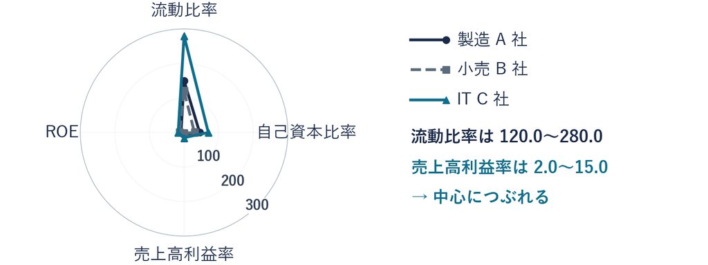

流動比率だけが外へ張り出し、売上高利益率は中心につぶれる

- **サンプルデータ**：lec2-exercise.xlsx の「比率」シート

## 指数で重ねたレーダー

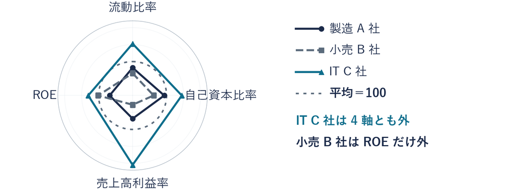

100 の円より外ほど、その指標が 3 社平均より高い

- **サンプルデータ**：lec2-exercise.xlsx の「比率」シート

## レーダーチャートの読み方

用語

**レーダーチャート**＝指標の軸を放射状に並べ  
各社の値を線で結んだグラフ

- **読み方**：外へ膨らむほど高い。指数で描くと 100 の円が平均
- **形が見える**：IT C 社は 4 軸とも外。小売 B 社は ROE だけ外
- **棒との違い**：棒は 1 指標の大小、レーダーは多指標の形

水準をそろえてから重ねると、形が比べられる

## 3 社のレーダー

1. **選ぶ**：A26:D30 を選ぶ  
   （A26 は空のまま）
2. **描く**：「挿入」タブの  
   グラフから「レーダー」
3. **題**：グラフの題を  
   「3社の形くらべ」に

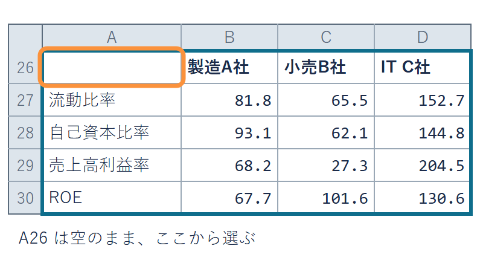

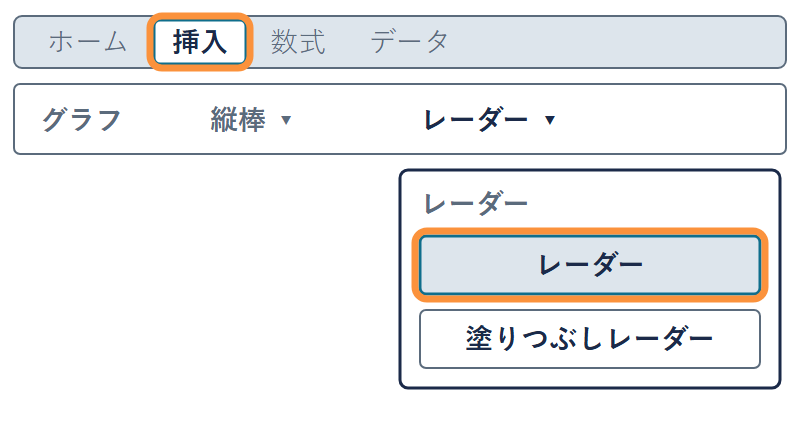

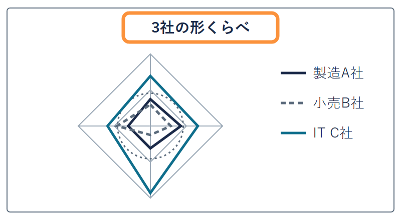

✋ 動画を止めて STEP 1〜3 を進め、線が 3 本出たら再生に戻る

## ヤマトと SG の形

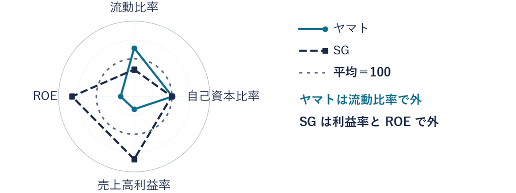

- **ヤマト**：流動比率の軸で外（128.6）。自己資本比率はほぼ 100
- **SG**：売上高利益率（166.2）と ROE（164.3）で外

出典：ヤマト 有価証券報告書 第161期（PDF 81〜85 ページ）  
SG 有価証券報告書 第20期（PDF 83〜85 ページ）の掲載値から計算

## 2 社のレーダー

1. **選ぶ**：A26:A30 を選び、Ctrl を  
   押しながら F26:G30
2. **描く**：レーダーを挿入し  
   題を「2社の形くらべ」に

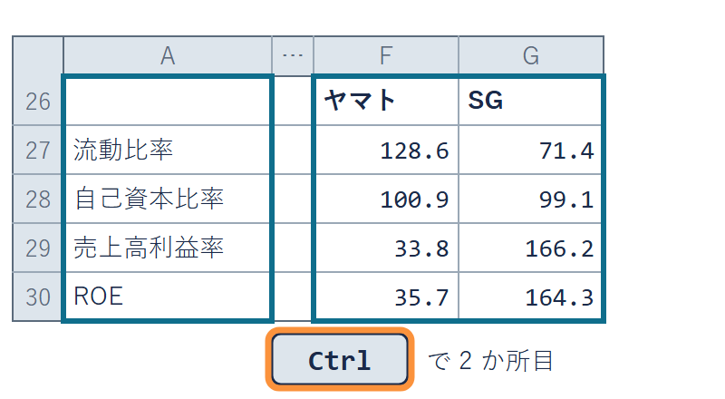

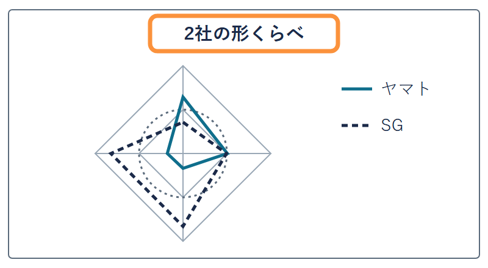

2 社・1 年分の形。これだけで良い会社とは決めない

✋ 動画を止めて STEP 1・2 を進め、線が 2 本出たら再生に戻る

## 演習 2-4-3 純資産の増加と形

演習 2-4-3

小売 B 社の純資産が 2 倍になると、ROE の軸は 100 の内か外か

1. **変える場所**：C11（小売 B 社の純資産）を 900 から 1,800 に
2. **考える問い**：C30（ROE の指数）は 100 の内か外か。ほかに動く軸は
3. **答えを打つ**：K17 に C30、K18 にほかに動いた軸の指数を打つ
4. **終わりの条件**：K17・K18 に打ったら、C11 を 900 に戻す

✋ 動画を止めて 2 分。K17・K18 に打ち、C11 を戻したら再生に戻る

## 演習 2-4-3 の答え

演習 2-4-3 の答え

ROE の軸は 100 の内（C30 は 61.2）

- **ROE**：120 ÷ 1,800 × 100 → 6.7。101.6 から 61.2 へ下がる
- **もう 1 本**：自己資本比率が 60.0 になり、C28 は 102.9 で外へ
- **考え方**：総資産の 3,000 は変えず、借入が減ったと考える
- **答え欄**：K17 に 61.2、K18 に 102.9（C28）と打てていれば正解

## まとめ

- **集合縦棒**：1 つの指標の大小を、棒の高さで比べる
- **指数**：値 ÷ 基準の値 × 100（今回は平均を 100 にそろえた）
- **レーダー**：指数で重ねると、多指標の形が比べられる
- **この回でそろえたもの**：出どころ・売上と元手・前の年・平均

絶対額では比べられない  
相対（比率）にそろえて、はじめて比べられる